# Excursions

Marie Gilbertson

2025-08-07

## Introduction

In this report, I demo the process we used to:

1. Identify extra-home-range movements (excursions) of white-tailed deer
2. Fit survival models to determine if excursion durations vary between chronic wasting disease (CWD) cases and controls

In the interest of keeping this report focused on novel or lesser-used methods, linear and logistic regressions are not included; these methods are common and our code is not unique.

For data ownership reasons, the data is not publicly available. However, I will preview the data structure so others can adapt this approach for themselves. Readers interested in data access should contact Daniel Storm at the Wisconsin Department of Natural Resources.

We’ll start by loading the packages we’ll need, as well as a couple of custom functions for later use. I also always set my seed as standard practice (this makes randomization reproducible).

```r
#### Clear Environment ####
remove(list=ls())


#### set seed ####
set.seed(89462)


#### load libraries ####
library(adehabitatLT)
library(ggplot2)
library(plyr)
library(dplyr)
library(lubridate)
library(amt)
library(ggpubr)
library(ctmm)
library(move)
library(sf)
library(units)
library(anomalize)
library(RColorBrewer)
library(MetBrewer)
library(lme4)
library(pscl)
library(MASS)
library(boot)
library(lmerTest)
library(sjPlot)
library(GGally)
library(arm)
library(DHARMa)
library(icenReg)
library(interval)

#### load custom functions ####

## function for numbering unique excursion events
number.events <- function(cand.ex){
  cand.ex$ex.event <- 0


  # if first location is an anomaly (should not be, but let's be safe)
  if(cand.ex$anomaly[1]=="Yes"){
    event.num <- 1
  }else if(cand.ex$anomaly[1]=="No"){
    event.num <- 0
  }
  cand.ex$ex.event[1] <- event.num

  for(j in 2:nrow(cand.ex)){

    # if this row isn't an anomaly, skip
    if(cand.ex$anomaly[j]=="No") next


    # if it is an anomaly, proceed with numbering
    if(cand.ex$anomaly[j]=="Yes"){

      # if an anomaly, was the preceeding row an anomaly? If not, this is a new event and gets a new number; otherwise, we keep the old number
      if(cand.ex$anomaly[j-1]=="No"){
        event.num <- event.num + 1
      }

      cand.ex$ex.event[j] <- event.num

    }

  }

  return(cand.ex)
}


## function for calculating the distance between two points
euc.dist <- function(x1, y1, x2, y2){
  out <- sqrt(((y2-y1)^2) + ((x2-x1)^2))
  return(out)
}
```

### Load data

Let’s load and preview the movement data for CWD cases and controls. The movement data is in “point” format. Net-squared displacement values were generated using the adehabitatLT package (movement data was made into an “ltraj” object, and then converted back to a dataframe). The column “R2n” gives each point’s net-squared displacement value.

We’ll also load previously calculated data documenting the monthly range centroid for each individual. This will be used to calculate the distance of excursion events.

```r
## load movement data
coll <- get(load("../Project_data/excursion_movement_data.Rdata"))
str(coll)
```

```
## 'data.frame':    28721 obs. of  16 variables:
##  $ x        : num  513725 513531 513559 513063 513614 ...
##  $ y        : num  281213 281295 281338 281178 281217 ...
##  $ date     : POSIXct, format: "2014-09-26 05:00:55" "2014-09-26 18:00:29" ...
##  $ dx       : num  -194 28 -496 551 -560 ...
##  $ dy       : num  81.9 42.4 -159.5 38.8 670.9 ...
##  $ dist     : num  210.5 50.8 520.8 552.1 873.7 ...
##  $ dt       : num  46774 46800 46800 46800 46818 ...
##  $ R2n      : num  0 44313 42977 439068 12324 ...
##  $ abs.angle: num  2.742 0.987 -2.8304 0.0704 2.2661 ...
##  $ rel.angle: num  NA -1.75 2.47 2.9 2.2 ...
##  $ id       : chr  "5006" "5006" "5006" "5006" ...
##  $ burst    : chr  "5006" "5006" "5006" "5006" ...
##  $ pair.id  : chr  "20" "20" "20" "20" ...
##  $ class    : chr  "case" "case" "case" "case" ...
##  $ mpd      : num  6 6 6 6 6 6 6 6 6 6 ...
##  $ odays    : Date, format: "2014-09-26" "2014-09-26" ...
```

```r
## load metadata
data <- get(load("../Project_data/case_control_collar_and_metadata.Rdata"))
## case-control metadata
meta <- data$meta.data

## load monthly range centroids for all individuals
cent.dat <- get(load("../Project_data/monthly_od_centroids.Rdata"))
str(cent.dat)
```

```
## tibble [415 × 6] (S3: tbl_df/tbl/data.frame)
##  $ id     : chr [1:415] "5022" "5022" "5022" "5022" ...
##  $ pair.id: chr [1:415] "1" "1" "1" "1" ...
##  $ class  : chr [1:415] "control" "control" "control" "control" ...
##  $ mpd    : num [1:415] 6 5 4 3 2 1 6 5 4 3 ...
##  $ x      : num [1:415] 524053 524041 524132 524125 524126 ...
##  $ y      : num [1:415] 288377 288381 288424 288425 288403 ...
```

### Identify candidate excursions

To identify candidate excursions, we’ll use each individual’s net-squared displacement. Specifically, we’ll look for “anomalous” spikes in net-squared displacement, as these can indicate that an individual has left their normal range. Movement data can be messy and we have variable fix rates between individuals, so I chose to use the daily mean net-squared displacement (NSD) for each individual. This means I was “smoothing” over some of the variation in NSD, which should reduce the number of “false positive” excursion detections.

We’ll start out by looking at a single example of using anomaly detection with NSD. I’ll show both “raw” NSD and daily averaged NSD.

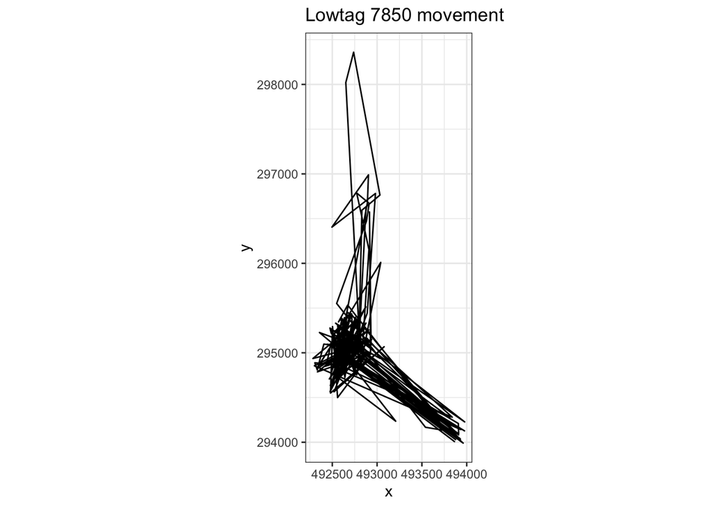

```r
# extract movement data for the example individual
temp.coll <- collm[collm$id==7850,]
temp.coll <- temp.coll[order(temp.coll$date),] # make sure it's in order
temp.coll$pt.index <- paste(temp.coll$id, seq(1, nrow(temp.coll)), sep = "_") # assign a unique index number to each point location

## plot the movement data for this individual
ggplot(temp.coll, aes(x = x, y = y)) +
  geom_path() +
  coord_fixed() + theme_bw() + ggtitle("Lowtag 7850 movement")
```

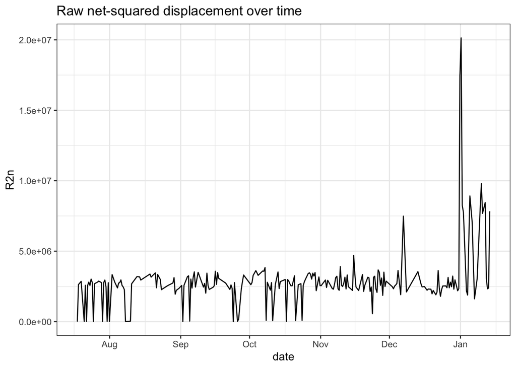

```r
### raw net-squared displacement over time
ggplot(temp.coll, aes(x = date, y = R2n)) +
  geom_path() +
  theme_bw() + ggtitle("Raw net-squared displacement over time")
```

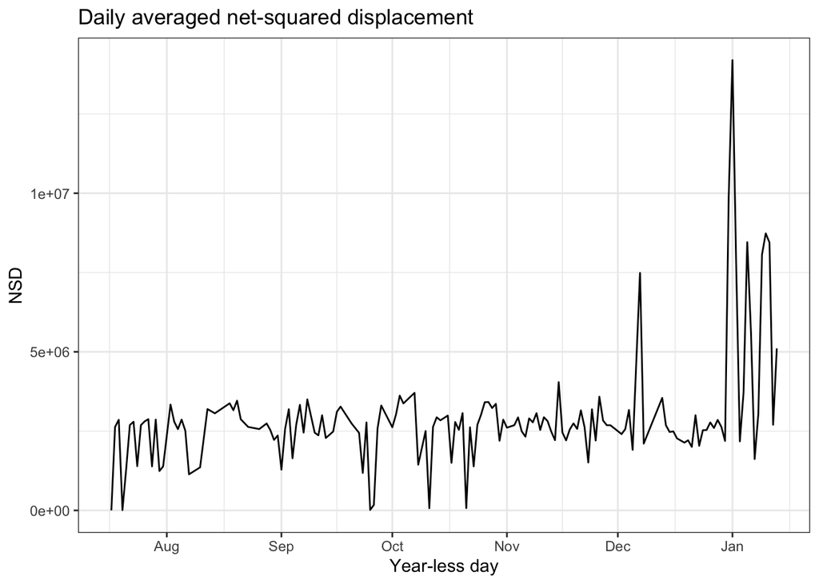

```r
### daily-averaged NSD
# calculate daily mean NSD for the i'th individual
daily.nsd <- ddply(temp.coll, .(odays), function(x) mean(x$R2n))
t <- tibble(daily.nsd) # convert to a tibble for anomaly detection

ggplot(daily.nsd, aes(x = odays, y = V1)) +
  geom_path() + xlab("Year-less day") + ylab("NSD") +
  theme_bw() + ggtitle("Daily averaged net-squared displacement")
```

Let’s look at anomaly detection for the raw and averaged NSD values.

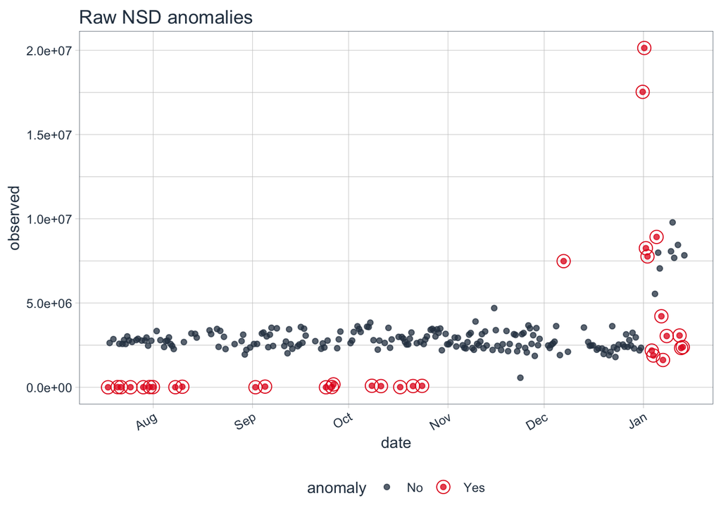

```r
#### detect anomalies among raw NSD ####
q <- tibble(temp.coll)
t_ano <- data.frame(matrix(nrow = 0, ncol = 1))
suppressMessages(t_ano <- q %>%
  time_decompose(R2n, merge = T) %>%
  anomalize(remainder) %>%
  time_recompose()
)

t_ano %>% plot_anomalies(ncol = 3, alpha_dots = 0.75) + ggtitle("Raw NSD anomalies")
```

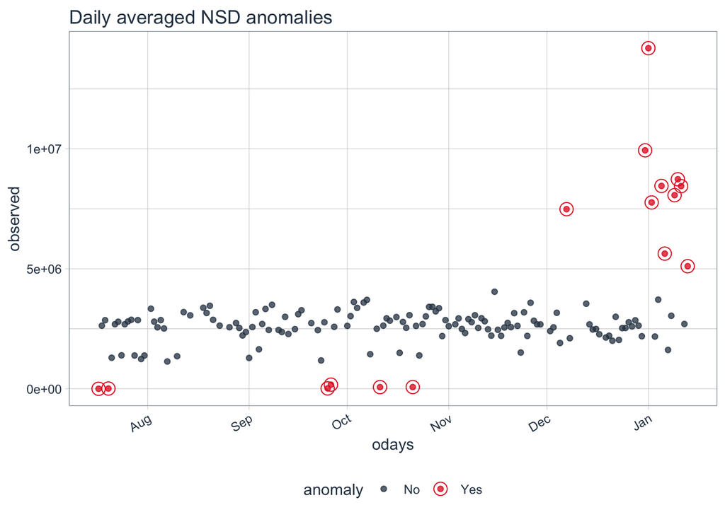

```r
#### detect anomalies among daily mean NSD ####
## use anomalize package for anomaly detection of NSD
t_ano <- data.frame(matrix(nrow = 0, ncol = 1))
suppressMessages(t_ano <- t %>%
  time_decompose(V1, merge = T) %>%
  anomalize(remainder) %>%
  time_recompose()
)

t_ano %>% plot_anomalies(ncol = 3, alpha_dots = 0.75) + ggtitle("Daily averaged NSD anomalies")
```

We can see that the anomaly detection picks up the movements where lowtag 7850 moved well outside its normal home range, but there can be a lot of “noise” in these detections. Using the daily-averaged NSD values seems to reduce some of the noise, while keeping the clearer excursion examples. We’ll use this method now in a loop to look for and extract data about anomalous NSD events for all our individuals.

```r
ids <- unique(collm$id) # loop through each individual
excursions.dat <- NULL  # to store the movement data associated with excursions
exc.dist.dat <- NULL    # to store meta-data associated with each excursion (namely, the distance of the excursion)

for(i in 1:length(ids)){

  # extract movement data for the i'th individual
  temp.coll <- collm[collm$id==ids[i],]
  temp.coll <- temp.coll[order(temp.coll$date),] # make sure it's in order
  temp.coll$pt.index <- paste(temp.coll$id, seq(1, nrow(temp.coll)), sep = "_") # assign a unique index number to each point location



  #### detect anomalies among daily mean NSD ####

  # calculate daily mean NSD for the i'th individual
  daily.nsd <- ddply(temp.coll, .(odays), function(x) mean(x$R2n))
  t <- tibble(daily.nsd) # convert to a tibble for anomaly detection

  ## try anomaly detection; if the time series is short, will make plot of movement and skip to next individual
  t_ano <- data.frame(matrix(nrow = 0, ncol = 1))
  try(suppressMessages(t_ano <- t %>%
    time_decompose(V1, merge = T) %>%
    anomalize(remainder) %>%
    time_recompose()),
    silent = T
  )

  if(nrow(t_ano)==0){
    p <- ggplot() +
      geom_path(data = temp.coll, aes(x = x, y = y)) +
      coord_fixed() +
      theme_bw()


    # plot.name <- paste0("Figures/Excursions/", ids[i], "/excursionplot_", ids[i], "_event_0.jpeg")
    # suppressMessages(ggsave(plot.name, p, width = 7, height = 7, dpi = 300))

    # save back NA's for anomaly data if not enough movement data to evaluate
    temp.dists <- data.frame(id = ids[i],
                             event = 0,
                             mpd = NA,
                             max.dist_m = NA)
    exc.dist.dat <- rbind(exc.dist.dat, temp.dists)

    next # skip to next individual
  }

  ## if an anomalies were detected, link the movement data with the anomaly data by day
  ano.data <- left_join(temp.coll, t_ano[,c("odays", "anomaly")], by = "odays")



  #### number anomaly events ####
  ano.data.num <- number.events(ano.data) # each unique anomaly gets a unique identifier



  ## if at least one anomaly exists, get it's max distance ##
  #### max distance to monthly range center per event ####
  ## use the monthly range center from the month in which the excursion started
  if(max(unique(ano.data.num$ex.event))>0){
    temp.dists <- NULL
    events <- unique(ano.data.num$ex.event)
    events <- events[events!=0]

    for(j in 1:length(events)){ # loop through unique anomaly events

      temp.dat <- ano.data.num[ano.data.num$ex.event==events[j],]

      # centroid for the earliest month associated with an ecxursion (i.e., when the excursion started)
      temp.month <- max(temp.dat$mpd)
      temp.cent <- cent.dat[cent.dat$id==ids[i] & cent.dat$mpd==temp.month,]
      # distance between centroid and the points associated with the excursion/anomaly event
      temp.dat$cent.dist <- NA
      for(k in 1:nrow(temp.dat)){
        temp.dat$cent.dist[k] <- euc.dist(x1 = temp.cent$x, y1 = temp.cent$y,
                                          x2 = temp.dat$x[k], y2 = temp.dat$y[k])
      }
      # save back only the maximum distance
      td <- data.frame(id = ids[i],
                       event = events[j],
                       mpd = temp.month,
                       max.dist_m = max(temp.dat$cent.dist))

      temp.dists <- rbind(temp.dists, td)

      ## make and save a plot showing the movement data, the unique excursion, and the points used to calculate the max excursion distance
      p <- ggplot() +
        geom_path(data = ano.data.num, aes(x = x, y = y)) +
        geom_path(data = temp.dat, aes(x = x, y = y), colour = "red") +
        geom_point(data = temp.dat, aes(x = x, y = y), colour = "red") +
        geom_point(data = temp.dat[temp.dat$cent.dist==max(temp.dat$cent.dist),], aes(x = x, y = y), fill = "gold", size = 4, pch = 23) +
        geom_point(data = temp.cent, aes(x = x, y = y), fill = "dodgerblue2", size = 4, pch = 22) +
        coord_fixed() +
        theme_bw()


      # plot.name <- paste0("../Figures/Excursions/", ids[i], "/excursionplot_", ids[i], "_event_", events[j], ".jpeg")
      # suppressMessages(ggsave(plot.name, p, width = 7, height = 7, dpi = 300))

    }

    # save completed distance data if there is at least one anomaly
    exc.dist.dat <- rbind(exc.dist.dat, temp.dists)
  }else{

    # if there was enough data to look for excursions but none were detected, save back a plot of the movement data
    p <- ggplot() +
      geom_path(data = ano.data.num, aes(x = x, y = y)) +
      coord_fixed() +
      theme_bw()


    # plot.name <- paste0("../Figures/Excursions/", ids[i], "/excursionplot_", ids[i], "_event_0.jpeg")
    # suppressMessages(ggsave(plot.name, p, width = 7, height = 7, dpi = 300))
  }

  # save back excursion data, regardless of number of anomalies/excursions
  excursions.dat <- rbind(excursions.dat, ano.data.num)


}

## add case/control info to the candidate excursion metadata
exc.dist.dat$class <- ifelse(exc.dist.dat$id %in% meta$cand.case, "case", "control")


## when running, don't forget to save!
excursions.out <- list(excursions.dat, exc.dist.dat)
names(excursions.out) <- c("excursions.dat", "exc.dist.dat")
# save(excursions.out, file = "../Project_data/excursions_out.Rdata")

str(excursions.dat)
```

```
## 'data.frame':    28676 obs. of  19 variables:
##  $ x        : num  513725 513531 513559 513063 513614 ...
##  $ y        : num  281213 281295 281338 281178 281217 ...
##  $ date     : POSIXct, format: "2014-09-26 05:00:55" "2014-09-26 18:00:29" ...
##  $ dx       : num  -194 28 -496 551 -560 ...
##  $ dy       : num  81.9 42.4 -159.5 38.8 670.9 ...
##  $ dist     : num  210.5 50.8 520.8 552.1 873.7 ...
##  $ dt       : num  46774 46800 46800 46800 46818 ...
##  $ R2n      : num  0 44313 42977 439068 12324 ...
##  $ abs.angle: num  2.742 0.987 -2.8304 0.0704 2.2661 ...
##  $ rel.angle: num  NA -1.75 2.47 2.9 2.2 ...
##  $ id       : chr  "5006" "5006" "5006" "5006" ...
##  $ burst    : chr  "5006" "5006" "5006" "5006" ...
##  $ pair.id  : chr  "20" "20" "20" "20" ...
##  $ class    : chr  "case" "case" "case" "case" ...
##  $ mpd      : num  6 6 6 6 6 6 6 6 6 6 ...
##  $ odays    : Date, format: "2014-09-26" "2014-09-26" ...
##  $ pt.index : chr  "5006_1" "5006_2" "5006_3" "5006_4" ...
##  $ anomaly  : Named chr  "No" "No" "No" "No" ...
##   ..- attr(*, "names")= chr [1:28676] "25%" "25%" "25%" "25%" ...
##  $ ex.event : num  0 0 0 0 0 0 0 0 0 0 ...
```

```r
str(exc.dist.dat)
```

```
## 'data.frame':    268 obs. of  5 variables:
##  $ id        : chr  "5006" "5006" "5006" "5006" ...
##  $ event     : num  1 2 3 4 5 6 7 1 2 3 ...
##  $ mpd       : num  4 2 2 2 1 1 1 5 4 4 ...
##  $ max.dist_m: num  1127 673 919 762 899 ...
##  $ class     : chr  "case" "case" "case" "case" ...
```

We’ve now identified candidate excursions for all our individuals. However, these are just “candidate” events, and require additional processing.

### Exclude months with dispersals

When detecting excursions, it’s important to exclude dispersal events as these are fundamentally different from excursions. In addition, depending on the research question, you may want to exclude some amount of time pre- and even post-dispersal, as individuals may be more likely to make excursions in “preparation” for dispersal. I’m skipping over the code process of excluding dispersals here because it’s just a lot of data wrangling code based on dispersal data from a [previous dispersal study](https://link.springer.com/article/10.1186/s40462-022-00342-5) we did, and nothing novel - but noting it as an important step in the overall process.

### Screen candidate excursions

We’ve automated identification of candidate excursions, but as we’ll see, many of these are not what we would consider true or likely excursions. Of course, we can’t ever truly tell what’s a real excursion and what’s, say, data error. As such, screening candidate excursions will inevitably be a bit subjective.

From a CWD perspective, I would argue that we are most concerned with long distance and long duration excursions. Long distance excursions can spread CWD to unexpected areas, relative to the extent of a deer’s normal home range. Long duration excursions provide more opportunity for an infectious individual to transmit to others or shed prions into the environment. Longer distance and longer duration excursions should be more “obvious” when looking at a map of an individual’s locations, with points being far from the main range and/or multiple consecutive relocations occurring outside the main range.

With these considerations in mind, I want to focus my analysis on these more obvious excursion events. Yes, I may miss some excursion events - especially those that are short distance or short duration (i.e., reduced sensitivity in excursion detection) - but because these are arguably less relevant for CWD transmission, I consider this an acceptable compromise. Especially because, as I’ll show below, we have a lot of “false positive” excursions and I don’t want to bias subsequent analysis with these excursions. In other words, I’m prioritizing specificity in excursion detection over sensitivity.

Let’s look at examples of candidate excursions that are likely “false detections”, real excursions, and ambiguous. Here’s a plot of the movement data for deer number 7850.

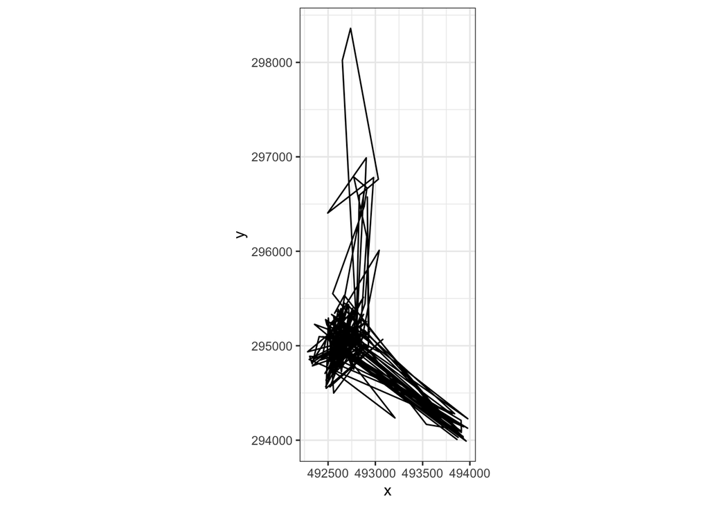

```r
## "excursions.dat.nd" is the same as "excursions.dat" in structure - it just has disersal events removed (nd = no dispersals)
temp.exc.dat <- excursions.dat.nd[excursions.dat.nd$id==7850,]

ggplot() +
  geom_path(data = temp.exc.dat, aes(x = x, y = y)) +
  coord_fixed() +
  theme_bw()
```

We can see that this individual had a “core range” with a lot of movements to the southeast and some less frequent movements to the north. The anomaly detection program identified 9 candidate excursions from this movement data, but let’s look a little closer at some of these. This time, we’ll plot just the first candidate excursion and we’ll add the home range centroid for the month in which this candidate excursion occurred.

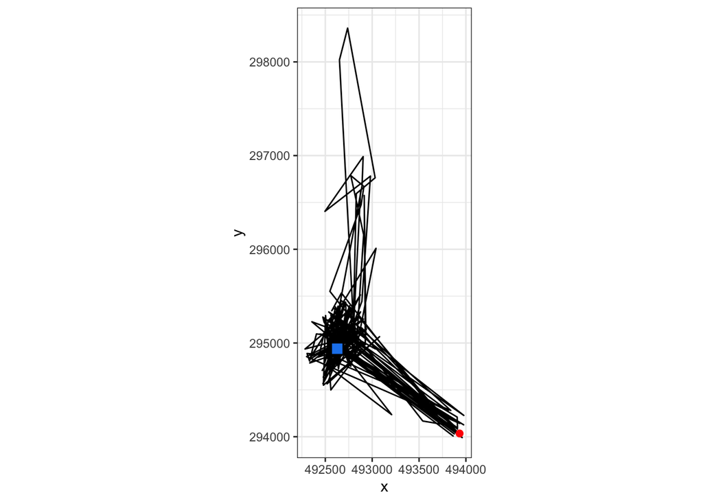

```r
temp.exc1 <- excursions.dat.nd[excursions.dat.nd$id==7850 & excursions.dat.nd$ex.event==1,]

temp.cent <- cent.dat[cent.dat$id==7850 & cent.dat$mpd==min(temp.exc1$mpd),]

ggplot() +
  geom_path(data = temp.exc.dat, aes(x = x, y = y)) +
  geom_path(data = temp.exc1, aes(x = x, y = y), colour = "red") +
  geom_point(data = temp.exc1, aes(x = x, y = y), colour = "red", size = 2) +
  geom_point(data = temp.cent, aes(x = x, y = y), fill = "dodgerblue2", size = 4, pch = 22) +
  coord_fixed() +
  theme_bw()
```

The red dot is the single location associated with this candidate excursion, and the blue square is the home range centroid for that month. While the candidate excursion falls outside the “normal core range,” this is a short duration event to a location this individual apparently frequents. As such, I would not consider this a true excursion.

Let’s look at the 7th candidate excursion for this individual.

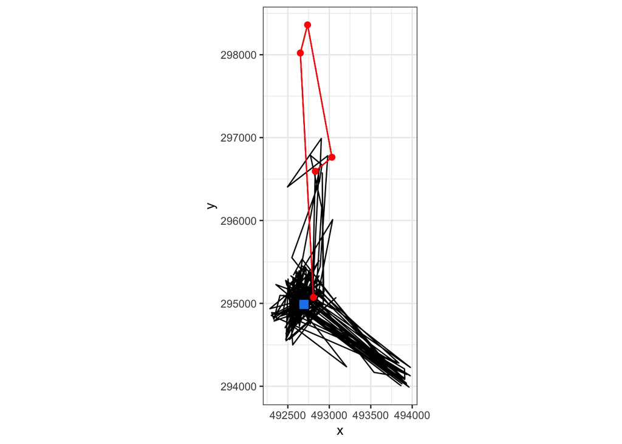

```r
temp.exc1 <- excursions.dat.nd[excursions.dat.nd$id==7850 & excursions.dat.nd$ex.event==7,]

temp.cent <- cent.dat[cent.dat$id==7850 & cent.dat$mpd==min(temp.exc1$mpd),]

ggplot() +
  geom_path(data = temp.exc.dat, aes(x = x, y = y)) +
  geom_path(data = temp.exc1, aes(x = x, y = y), colour = "red") +
  geom_point(data = temp.exc1, aes(x = x, y = y), colour = "red", size = 2) +
  geom_point(data = temp.cent, aes(x = x, y = y), fill = "dodgerblue2", size = 4, pch = 22) +
  coord_fixed() +
  theme_bw()
```

Here, we see a longer duration and distance candidate excursion than the previous one we examined. In addition, this excursion is to a novel or otherwise uncommonly visited area. I would consider this a true excursion.

Of course, not all candidate excursions are particularly clear. Let’s look at another candidate excursion for this individual.

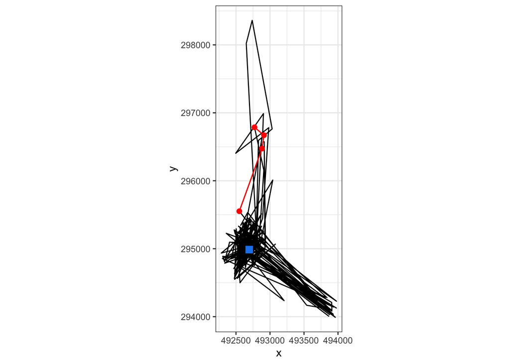

```r
temp.exc1 <- excursions.dat.nd[excursions.dat.nd$id==7850 & excursions.dat.nd$ex.event==8,]

temp.cent <- cent.dat[cent.dat$id==7850 & cent.dat$mpd==min(temp.exc1$mpd),]

ggplot() +
  geom_path(data = temp.exc.dat, aes(x = x, y = y)) +
  geom_path(data = temp.exc1, aes(x = x, y = y), colour = "red") +
  geom_point(data = temp.exc1, aes(x = x, y = y), colour = "red", size = 2) +
  geom_point(data = temp.cent, aes(x = x, y = y), fill = "dodgerblue2", size = 4, pch = 22) +
  coord_fixed() +
  theme_bw()
```

This event is similar to the previous one, but this deer does revisit this area on several occasions. Is this a real excursion? I’m not sure we can say. I would classify this event as “ambiguous.”

These are just a few examples from a single individual, but I used these same basic principles to screen all candidate excursions. I’ve included the code below, but this process was ultimately a subjective review of each candidate excursion in which I classified each event as a likely excursion (“ok”), a likely false excursion (“bad”), or “ambiguous.” In addition, there wasn’t perfect overlap between individuals included in this study and those included in the original dispersal study, so I also screened for evidence of dispersal events.

```r
## all candidate excursions have a unique identifier (we'll loop through these)
evtids <- unique(excursions.dat.nd$evtid[excursions.dat.nd$ex.event!=0])
i <- 1
exc.screen <- data.frame(evtids = evtids,
                         id = NA,
                         mpd = NA,
                         screen.result = NA)


repeat{

  ## extract data for the candidate excursion
  temp.exc.dat <- excursions.dat.nd[excursions.dat.nd$evtid==evtids[i],]
  temp.id <- unique(temp.exc.dat$id)
  if(length(temp.id)>1){
    stop("Multiple individuals")
  }

  temp.dat <- excursions.dat.nd[excursions.dat.nd$id==temp.id,]

  temp.cent <- cent.dat[cent.dat$id==temp.id & cent.dat$mpd==min(temp.exc.dat$mpd),]


  ## print plot of this candidate excursion in the context of the individual's movement data
  suppressMessages(
  print(ggplot() +
          geom_path(data = temp.dat, aes(x = x, y = y)) +
          geom_path(data = temp.exc.dat, aes(x = x, y = y), colour = "red") +
          geom_point(data = temp.exc.dat, aes(x = x, y = y), colour = "red", size = 2) +
          geom_point(data = temp.cent, aes(x = x, y = y), fill = "dodgerblue2", size = 4, pch = 22) +
          coord_fixed() +
          theme_bw()

        ))

  ## user prompted to provide a classification decision
  # ok = likely excursion
  # disp = likely dispersal event
  # bad = unlikely to be a real excursion
  # ambig = ambiguous; can't determine if excursion or not
  repeat{
    raw <- readline("Real excursion? Choices are: ok, disp, bad, ambig  ")

    if(raw %in% c("ok", "disp", "bad", "ambig"))break

    if(!raw %in% c("ok", "disp", "bad", "ambig")){
      print("Let's try that again...")
    }
  }


    exc.screen$id[i] <- temp.id
    exc.screen$mpd[i] <- min(temp.exc.dat$mpd)
    exc.screen$screen.result[i] <- raw


    ## user is prompted to input if they have changed their mind about this classification (e.g., in case of a mistype or too quick decision)
    regrets <- readline("Having regrets about that last one? Choices are: y or n  ")


    if(regrets=="n"){
      i <- i +1
    }else{
      "Ok, let's repeat that last one..."
    }

    if(i>length(evtids)) break
    if(i%%10==0){
      print(paste0("Progress: ", round((i/length(evtids))*100, 1), "%"))
    }
}

## save screening results
# save(exc.screen, file = "../Project_data/Excursions_screening_rawout.Rdata")
```

All screening choices were saved so there is a record of each decision. Let’s take a look at these screening results.

```r
exc.screen <- get(load("../Project_data/Excursions_screening_rawout.Rdata"))

head(exc.screen)
```

```
##   evtids   id mpd screen.result
## 1 5006_1 5006   4           bad
## 2 5006_2 5006   2           bad
## 3 5006_3 5006   2           bad
## 4 5006_4 5006   2           bad
## 5 5006_5 5006   1           bad
## 6 5006_6 5006   1           bad
```

```r
table(exc.screen$screen.result)
```

```
##
## ambig   bad    ok
##    21   128   116
```

We can see that a LOT of candidate excursions are pretty unequivocally “bad” but many of them do seem reasonable. In addition, while there are plenty ambiguous candidate events, it was generally pretty straightforward to make a call between excursion or not.

### Explore excursions

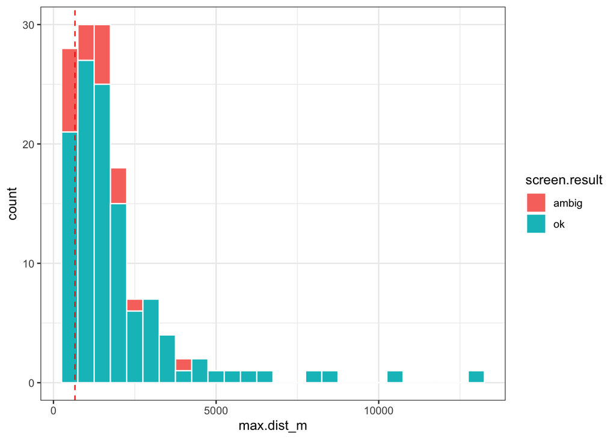

```r
## only the ok or ambiguous ones
ok.ambig <- exc.screen[exc.screen$screen.result %in% c("ok", "ambig"),]
excursions.dat.nd.scrn <- excursions.dat.nd[excursions.dat.nd$evtid %in% ok.ambig$evtids,]
exc.dist.dat.nd$evtid <- paste(exc.dist.dat.nd$id, exc.dist.dat.nd$event, sep = "_")
exc.dist.dat.nd.scrn <- exc.dist.dat.nd[exc.dist.dat.nd$evtid %in% ok.ambig$evtids,]

exc.oa <- left_join(exc.dist.dat.nd.scrn, exc.screen[,c("evtids", "screen.result")], by = c("evtid" = "evtids"))

ggplot(exc.oa, aes(x = max.dist_m, fill = screen.result)) +
  geom_histogram(binwidth = 500, colour = "white") +
  geom_vline(xintercept = 660, colour = "red", linetype = "dashed") +
  theme_bw()
```

We can see that ambiguous events are generally pretty short distance - which makes sense, given that we’ll feel more confident in an excursion if it’s long distance and/or long duration. In addition, we can see that excursion distances are skewed.

#### Excursion rates

From here on, let’s just focus on the excursions that we’re the most confident in. We’ll next look at the frequency of excursions, including calculating an excursion “rate,” where we divide the number of excursions by the number of days in which an individual was observed.

```r
exc.ok <- exc.oa[exc.oa$screen.result=="ok",]
exc.ok <- left_join(exc.ok, pair.key, by = c("id"))


## need to control for days observed, so do number of events per non-dispersal-days observed
# number of days observed overall
ndays.obs <- ddply(excursions.dat.nd, .(id, pair.id, class), function(x) length(unique(x$odays)))
# number of days observed per month pre-case-death
ndays.obs.mpd <- ddply(excursions.dat.nd, .(id, pair.id, class, mpd), function(x) length(unique(x$odays)))
colnames(ndays.obs)[colnames(ndays.obs)=="V1"] <- colnames(ndays.obs.mpd)[colnames(ndays.obs.mpd)=="V1"] <- "ndays.obs"

# number of excursion events overall
nevents <- ddply(exc.ok, .(id, pair.id, class), function(x) length(unique(x$event)))
# number of excursion events per month pre-case-death
nevents.mpd <- ddply(exc.ok, .(id, pair.id, class, mpd), function(x) length(unique(x$event)))
colnames(nevents)[colnames(nevents)=="V1"] <- colnames(nevents.mpd)[colnames(nevents.mpd)=="V1"] <- "nevents"

## join days observed and excursion counts together
exc.rate <- left_join(ndays.obs, nevents, by = c("id", "pair.id", "class"))
# an "NA" for "nevents" means there were no excursion events detected
exc.rate$nevents[is.na(exc.rate$nevents)] <- 0
exc.rate$exc.rate <- exc.rate$nevents/exc.rate$ndays.obs

## repeat for monthly data
exc.rate.mpd <- left_join(ndays.obs.mpd, nevents.mpd, by = c("id", "pair.id", "class", "mpd"))
exc.rate.mpd$nevents[is.na(exc.rate.mpd$nevents)] <- 0
exc.rate.mpd$exc.rate <- exc.rate.mpd$nevents/exc.rate.mpd$ndays.obs

## view data
head(exc.rate) # each line represents one deer
```

```
##     id pair.id   class ndays.obs nevents    exc.rate
## 1 5006      20    case       113       0 0.000000000
## 2 5022       1 control       158       2 0.012658228
## 3 5054       8    case       168       1 0.005952381
## 4 5060       4 control       162       2 0.012345679
## 5 5064      14    case       168       3 0.017857143
## 6 5177      17    case       174       3 0.017241379
```

```r
## add deer sex to the excursion data
exc.rate <- left_join(exc.rate, meta[,c("pair.id", "sex.x")], by = "pair.id")
exc.rate.mpd <- left_join(exc.rate.mpd, meta[,c("pair.id", "sex.x")], by = "pair.id")

## summarize number of excursion events overall
summary(exc.rate$nevents)
```

```
##    Min. 1st Qu.  Median    Mean 3rd Qu.    Max.
##   0.000   0.000   1.000   1.432   2.000   6.000
```

```r
## summarize excursion rates (events divided by days observed) overall
summary(exc.rate$exc.rate)
```

```
##     Min.  1st Qu.   Median     Mean  3rd Qu.     Max.
## 0.000000 0.000000 0.008475 0.012679 0.017544 0.096774
```

#### Fix rates during excursions

Our fix rates are probably affecting our ability to detect excursions, as well as the distance and duration of those excursions. So let’s determine the fix rate for each of our excursion events. The movement data has all been resampled previously, so fix rates should be fairly consistent within individuals (except for where a fix rate change resulted in a non-divisible fix rate; e.g., every 4 hours –> every 12 hours, but then every 13 hours has to stay at every 13).

```r
fix.rates.ov <- ddply(excursions.dat.nd, .(id, pair.id, class), function(x) round(median(x$dt/3600, na.rm = T),1)) # overall
fix.rates.mpd <- ddply(excursions.dat.nd, .(id, pair.id, class, mpd), function(x) round(median(x$dt/3600, na.rm = T),1)) # by month
colnames(fix.rates.ov)[colnames(fix.rates.ov)=="V1"] <- colnames(fix.rates.mpd)[colnames(fix.rates.mpd)=="V1"] <- "fix.rate.hrs"

## add fix rate info to ongoing datasets
exc.rate <- left_join(exc.rate, fix.rates.ov, by = c("id", "pair.id", "class"))
exc.rate.mpd <- left_join(exc.rate.mpd, fix.rates.mpd, by = c("id", "pair.id", "class", "mpd"))
exc.ok <- left_join(exc.ok, fix.rates.mpd, by = c("id", "pair.id", "class", "mpd"))
```

#### Excursion duration

I’m going to demonstrate testing for any differences in the duration of excursions. However, because GPS collar data isn’t continuous (there are time gaps between fixes), we can’t know precisely when an excursion started or when it ended.

Here’s what we know:

1. The start of the excursion should be sometime between the first anomalous observation and the observation immediately preceding that one.
2. The end of the excursion should be sometime between the last anomalous observation and the observation immediately following that one.

From an interval censoring perspective, the left side of the interval for duration (i.e., the shortest possible duration) should be: (last anomalous - first anomalous)

and the right side of the interval (i.e., the longest possible duration) should be: (first post-excursion non-anomalous - last pre-excursion non-anomalous)

Let’s make these calculations and add them to our dataset.

```r
exc.ok$dur.right.hrs <- exc.ok$dur.left.hrs <- NA

# loop through observed and screened excursions
for(i in 1:nrow(exc.ok)){

  temp.exc <- exc.ok[i,]

  temp.dat <- excursions.dat.nd[excursions.dat.nd$id==temp.exc$id,]


  temp.dat.anoms <- which(temp.dat$evtid==temp.exc$evtid)


  t1 <- temp.dat$date[min(temp.dat.anoms)-1]
  t2 <- temp.dat$date[min(temp.dat.anoms)]
  t3 <- temp.dat$date[max(temp.dat.anoms)]
  t4 <- temp.dat$date[max(temp.dat.anoms)+1]

  exc.ok$dur.left.hrs[i] <- as.numeric(difftime(t3, t2, units = "hours"))

  if(min(temp.dat.anoms)==1){
    t1 <- Inf ## if the first anomalous point is also the first point in the trajectory, "minimum start point" becomes infinity
  }

  if(max(temp.dat.anoms)==nrow(temp.dat)){
    t4 <- Inf ## if the last anomolous point is also the last point in the trajectory, "maximum end point" becomes infinity
  }

  exc.ok$dur.right.hrs[i] <- abs(as.numeric(difftime(t4, t1, units = "hours"))) # absolute value to deal with any "negative infinities"


}
```

### Do CWD cases travel for longer durations during excursions than controls?

Now we can statistically evaluate our excursion durations.

Unfortunately, we can’t be entirely confident in the duration of our detected excursions because we are not continuously monitoring animals. When we calculated “durations” above, we really were establishing the minimum and maximum durations for each excursion. Here, we defined the minimum duration as the time between the first and last anomalous net-squared displacement (NSD) fixes (which are really anomalous “days” because we evaluated daily average NSD). The maximum duration is the time difference between the fixes on “either side” of those anomalous points - the last non-anomalous fix before the first anomalous one, and the first non-anomalous fix after the last anomalous one.

In order to analyze these data, we can use a survival analysis (where the “time to event” is “time to end of excursion”) and use interval tools to accommodate the “interval” nature of our data.

Our main hypotheses are that excursion duration is affected by CWD class (case or control), and that this effect may vary by the number of months prior to death (e.g., we might expect a case’s excursion to be shorter in the month prior to death, as compared to six months prior to death; in contrast, we might not expect control excursions to vary in duration based on months prior to case death). In addition, we’ll include our fix rates in our modeling, as our duration estimates are likely affected by our fix rates.

We can use a Cox proportional hazards (PH) model with our interval data. However, we need to make sure that our model meets the assumptions of “proportional hazards.” To do so, we’ll follow recommendations from Kleinbaum and Klein (2005; “Survival Analysis: A Self-Learning Text), making observed (from Kaplan-Meier curves) versus expected (from PH models) plots for each of our candidate predictors. If a potential predictor violates the proportional hazards assumption, we’ll expect to see poor alignment between the observed and expected curves.

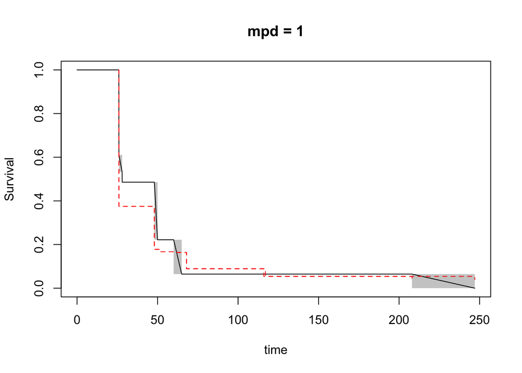

```r
ph.dat <- exc.ok
ph.dat$fix.rate.hrs_sc <- scale(ph.dat$fix.rate.hrs)[,1] # scale and center


## months prior to case death PH check
# expected
drm0 <- ic_sp(cbind(dur.left.hrs, dur.right.hrs) ~ mpd, model = "ph", bs_samples = 100, data = ph.dat)

# observed
drm1 <- icfit(Surv(time = dur.left.hrs, time2 = dur.right.hrs, type="interval2") ~ 1, conf.int = F, data = ph.dat[ph.dat$mpd==1,])
drm2 <- icfit(Surv(time = dur.left.hrs, time2 = dur.right.hrs, type="interval2") ~ 1, conf.int = F, data = ph.dat[ph.dat$mpd==2,])
drm3 <- icfit(Surv(time = dur.left.hrs, time2 = dur.right.hrs, type="interval2") ~ 1, conf.int = F, data = ph.dat[ph.dat$mpd==3,])
drm4 <- icfit(Surv(time = dur.left.hrs, time2 = dur.right.hrs, type="interval2") ~ 1, conf.int = F, data = ph.dat[ph.dat$mpd==4,])
drm5 <- icfit(Surv(time = dur.left.hrs, time2 = dur.right.hrs, type="interval2") ~ 1, conf.int = F, data = ph.dat[ph.dat$mpd==5,])
drm6 <- icfit(Surv(time = dur.left.hrs, time2 = dur.right.hrs, type="interval2") ~ 1, conf.int = F, data = ph.dat[ph.dat$mpd==6,])

newdata.mpd1 <- data.frame(mpd = 1)
newdata.mpd2 <- data.frame(mpd = 2)
newdata.mpd3 <- data.frame(mpd = 3)
newdata.mpd4 <- data.frame(mpd = 4)
newdata.mpd5 <- data.frame(mpd = 5)
newdata.mpd6 <- data.frame(mpd = 6)

plot(drm1, lwd = 2, main = "mpd = 1")
lines(drm0, newdata.mpd1, col = "red", lty = "dashed")
```

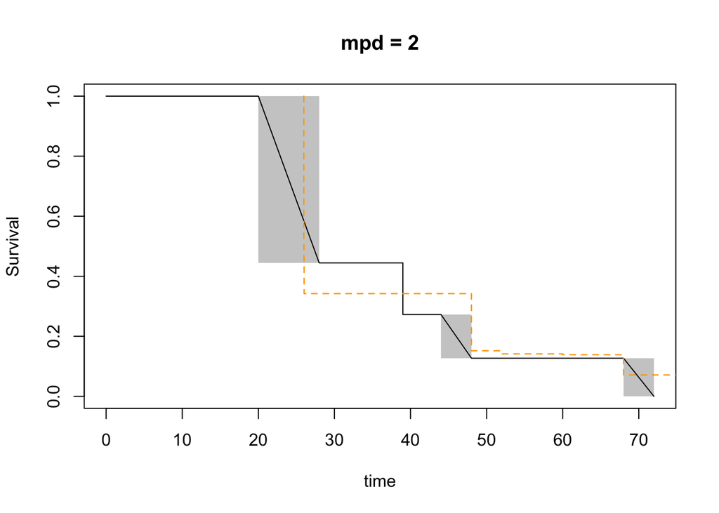

```r
plot(drm2, lwd = 2, main = "mpd = 2")
lines(drm0, newdata.mpd2, col = "orange", lty = "dashed")
```

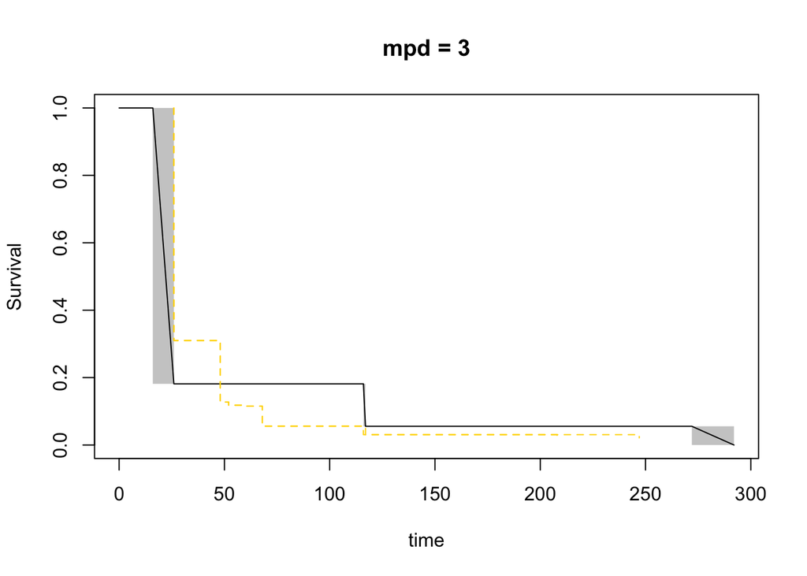

```r
plot(drm3, lwd = 2, main = "mpd = 3")
lines(drm0, newdata.mpd3, col = "gold", lty = "dashed")
```

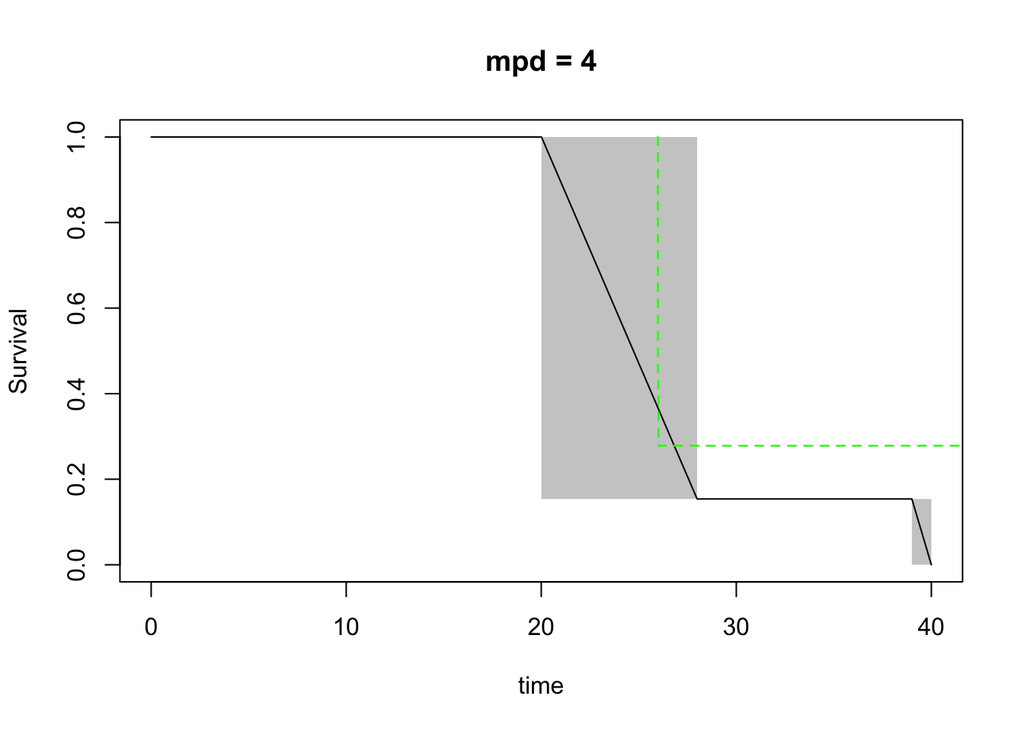

```r
plot(drm4, lwd = 2, main = "mpd = 4")
lines(drm0, newdata.mpd4, col = "green", lty = "dashed")
```

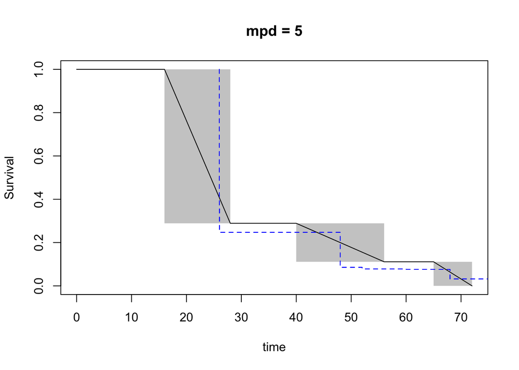

```r
plot(drm5, lwd = 2, main = "mpd = 5")
lines(drm0, newdata.mpd5, col = "blue", lty = "dashed")
```

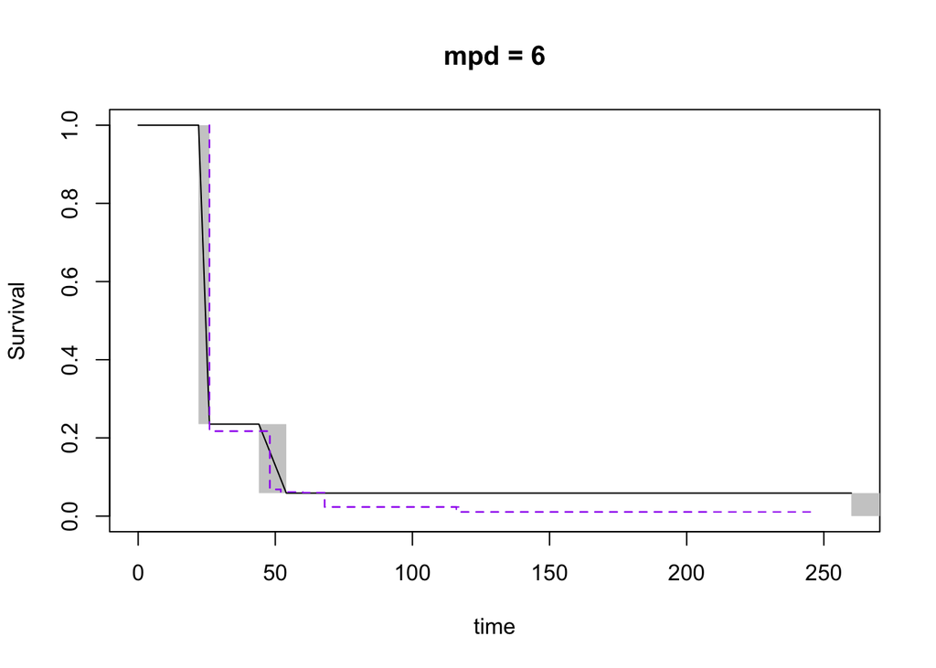

```r
plot(drm6, lwd = 2, main = "mpd = 6")
lines(drm0, newdata.mpd6, col = "purple", lty = "dashed")
```

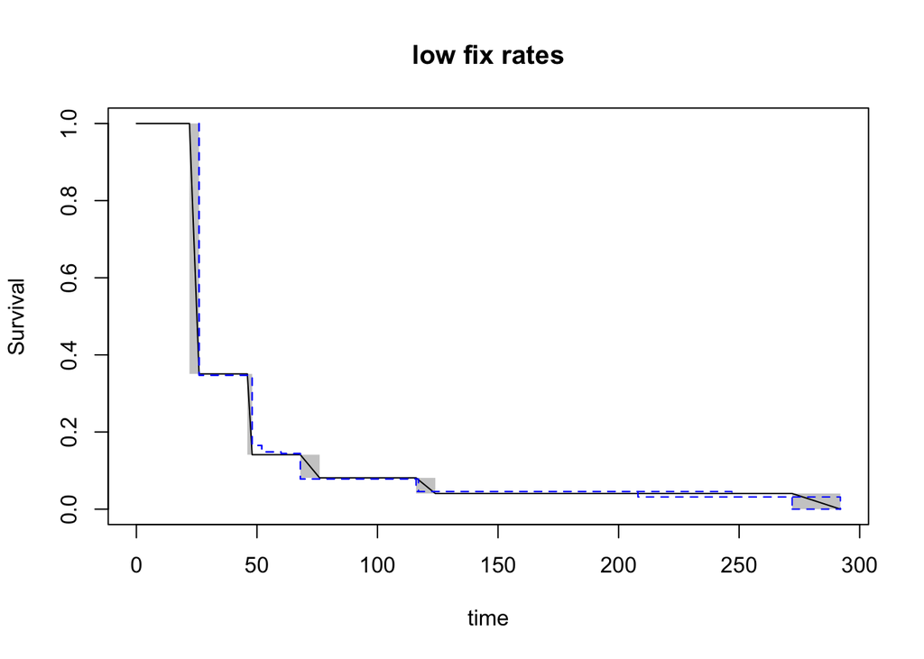

```r
## fix rate PH check
# stratify into categories
ph.dat$fix.rate.hrs_cat <- ifelse(ph.dat$fix.rate.hrs_sc<0, "low", "high")

# expected
drf0 <- ic_sp(cbind(dur.left.hrs, dur.right.hrs) ~ fix.rate.hrs_cat, model = "ph", bs_samples = 100, data = ph.dat)

# observed
drfl <- icfit(Surv(time = dur.left.hrs, time2 = dur.right.hrs, type="interval2") ~ 1, conf.int = F, data = ph.dat[ph.dat$fix.rate.hrs_cat=="low",])
drfh <- icfit(Surv(time = dur.left.hrs, time2 = dur.right.hrs, type="interval2") ~ 1, conf.int = F, data = ph.dat[ph.dat$fix.rate.hrs_cat=="high",])


newdata.low <- data.frame(fix.rate.hrs_cat = "low")
rownames(newdata.low) <- "low"

newdata.high <- data.frame(fix.rate.hrs_cat = "high")
rownames(newdata.high) <- "high"


plot(drfl, main = "low fix rates")
lines(drf0, newdata.low, col = "blue", lty = "dashed")
```

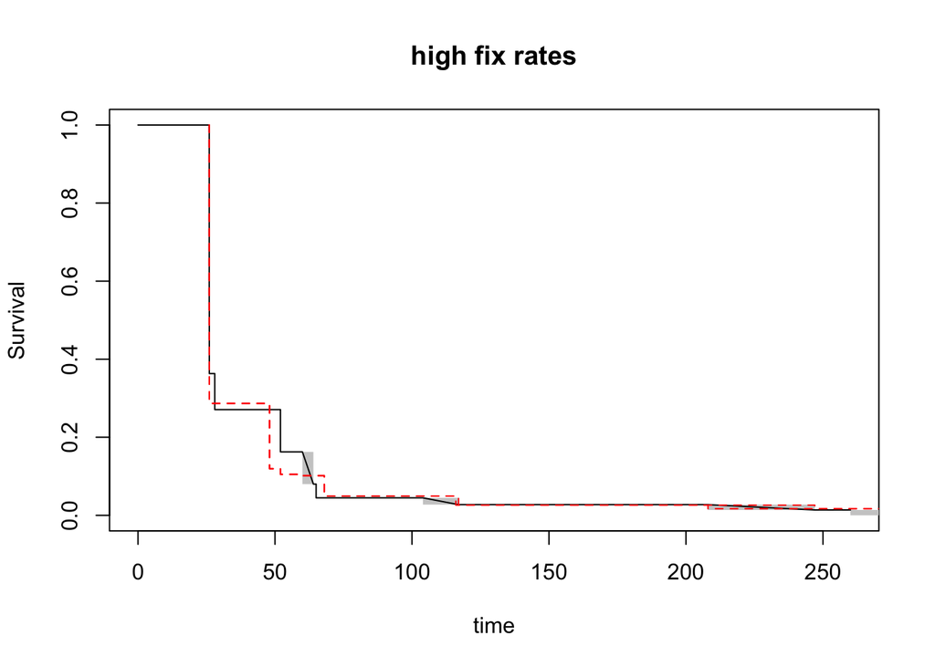

```r
plot(drfh, main = "high fix rates")
lines(drf0, newdata.high, col = "red", lty = "dashed")
```

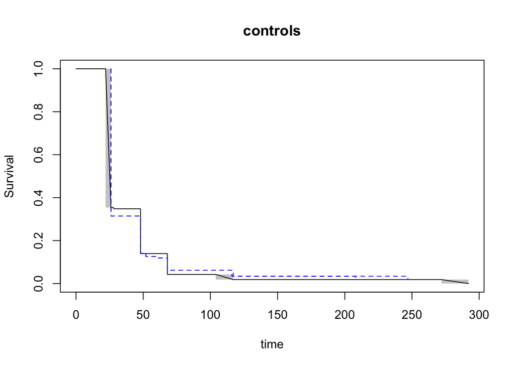

```r
## class PH check

# expected
drc0 <- ic_sp(cbind(dur.left.hrs, dur.right.hrs) ~ class, model = "ph", bs_samples = 100, data = ph.dat)

# observed
drccs <- icfit(Surv(time = dur.left.hrs, time2 = dur.right.hrs, type="interval2") ~ 1, conf.int = F, data = ph.dat[ph.dat$class=="case",])
drccl <- icfit(Surv(time = dur.left.hrs, time2 = dur.right.hrs, type="interval2") ~ 1, conf.int = F, data = ph.dat[ph.dat$class=="control",])

newdata.case <- data.frame(class = "case")
rownames(newdata.case) <- "case"

newdata.cntrl <- data.frame(class = "control")
rownames(newdata.cntrl) <- "control"


plot(drccl, main = "controls")
lines(drc0, newdata.cntrl, col = "blue", lty = "dashed")
```

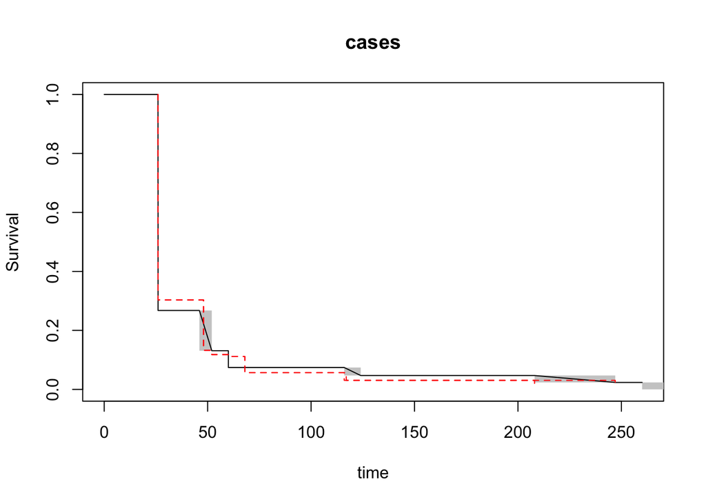

```r
plot(drccs, main = "cases")
lines(drc0, newdata.case, col = "red", lty = "dashed")
```

```r
### fit final model
dr1 <- ic_sp(cbind(dur.left.hrs, dur.right.hrs) ~ class + fix.rate.hrs_sc, model = "ph", bs_samples = 100, data = ph.dat)
dr1
```

```
##
## Model:  Cox PH
## Dependency structure assumed: Independence
## Baseline:  semi-parametric
## Call: ic_sp(formula = cbind(dur.left.hrs, dur.right.hrs) ~ class +
##     fix.rate.hrs_sc, data = ph.dat, model = "ph", bs_samples = 100)
##
##                 Estimate Exp(Est) Std.Error z-value      p
## classcontrol    -0.03388   0.9667   0.21290 -0.1591 0.8736
## fix.rate.hrs_sc  0.07881   1.0820   0.09721  0.8108 0.4175
##
## final llk =  -90.28834
## Iterations =  10
## Bootstrap Samples =  100
```

```r
mod.out <- data.frame(summary(dr1)$summaryParameters)
mod.out$Variable <- rownames(mod.out)
mod.out <- mod.out[,c("Variable", "Estimate", "Exp.Est.", "Std.Error", "p")]
colnames(mod.out) <- c("Variable", "Estimate", "Exp Est", "Standard error", "p-value")
# write.csv(mod.out, "../Output/Excursion_analysis/excursion_duration_semiparametric_results.csv", row.names = F)
```

From these results, we can see that there isn’t a statistically significant difference in excursion duration between cases and controls.

We can make a quick survival plot of just cases and controls at mean fix rates just to wrap things up.

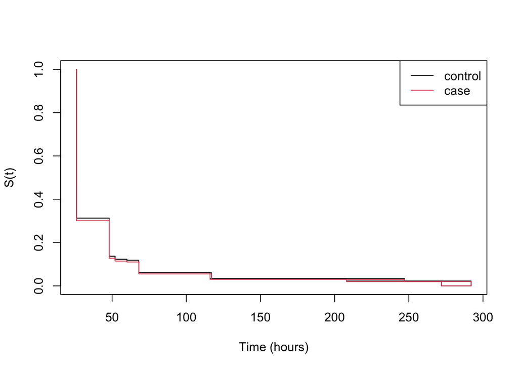

```r
newdata <- data.frame(class = c("control", "case"),
                      fix.rate.hrs_sc = c(0,0))
rownames(newdata) <- c("control", "case")

# jpeg("../Figures/Excursion_analysis/excursion_duration_semiparametric_survivalcurve.jpeg", width = 6, height = 5, units = "in", res = 300)
plot(dr1, newdata, xlab = "Time (hours)")
```

```r
# dev.off()
```

Plotting them thusly highlights the lack of significant difference between our two classes.